# Scraping data from APIs

Pablo Barbera

January 22, 2016

### Scraping web data from APIs

To understand how APIs work, we’ll take the New York Times API as an example. This API allows users to search articles by string and dates, and returns counts of articles and a short description of each article (but not the full text). You can find the documentation [here](http://developer.nytimes.com/docs/read/article_search_api_v2). Get a new API token and paste it here:

```r
apikey <- 'NYT_API_KEY'
```

The fist step is to identify the base url and the parameters that we can use to query the API. Now we can do a first API call using the `httr` package. (You can use my API key for now, let’s hope we don’t hit the rate limit!)

```r
base_url <- "http://api.nytimes.com/svc/search/v2/articlesearch.json"
# install.packages("httr")
library(httr)
r <- GET(base_url, query=list(q="inequality","api-key"=apikey))
r
```

```
## Response [http://api.nytimes.com/svc/search/v2/articlesearch.json?q=inequality&api-key=05e7c6c6f4896fba6c08531808067326%3A10%3A67731177]
##   Date: 2016-01-22 18:34
##   Status: 200
##   Content-Type: application/json; charset=UTF-8
##   Size: 18.9 kB
```

To extract the text returned by this API call, you can use `content`. You can write it to a file to take a look at it.

```r
content(r, 'text')
```

```r
writeLines(content(r, 'text'), con=file("nyt.json"))
```

We can save the output into an object in R to learn more about its structure.

```r
json <- content(r, 'parsed')
class(json); names(json) # list with 3 elements
```

```
## [1] "list"
```

```
## [1] "response"  "status"    "copyright"
```

```r
json$status # this should be "OK"
```

```
## [1] "OK"
```

```r
names(json$response) # the actual data
```

```
## [1] "meta" "docs"
```

```r
json$response$meta # metadata
```

```
## $hits
## [1] 14797
##
## $time
## [1] 20
##
## $offset
## [1] 0
```

If we check the documentation, we find that we can subset by date with the `begin_date` and `end_date` parameters. Let’s see how this works…

```r
r <- GET(base_url, query=list(q="inequality",
                              "api-key"=apikey,
                              "begin_date"=20140101,
                              "end_date"=20141231))
json <- content(r, 'parsed')
json$response$meta
```

```
## $hits
## [1] 1743
##
## $time
## [1] 43
##
## $offset
## [1] 0
```

Between these two dates, there were 1,743 articles in the NYT mentioning “inequality”.

Now imagine we want to look at the evolution of mentions of this word over time. Following the best coding practices we introduced the first day, we want to write a function that will take a word and a set of dates as arguments and return the counts of articles.

This would be a first draft of that function:

```r
nyt_count <- function(q, date1, date2){
  r <- GET(base_url, query=list(q=q,
                                "api-key"=apikey,
                                "begin_date"=date1,
                                "end_date"=date2))
  json <- content(r, "parsed")
  return(json$response$meta$hits)
}

nyt_count(q="inequality", date1=20160101, date2=20160122)
```

```
## [1] 129
```

Ok, so this seems to work. But we want to run this function multiple times, so let’s write another function that helps us do that.

```r
nyt_years_count <- function(q, yearinit, yearend){
  # sequence of years to loop over
  years <- seq(yearinit, yearend)
  counts <- rep(NA, length(years))
  # loop over periods
  for (i in 1:length(years)){
    # information message to track progress
    message(years[i])
    # retrieve count
    counts[i] <- nyt_count(q=q, date1=paste0(years[i], "0101"),
                           date2=paste0(years[i], "1231"))
  }
  return(counts)
}
```

```r
# and let's see what happens...
nyt_years_count(q="inequality", yearinit=1950, yearend=2014)
```

[output not shown]

```r
nyt_count <- function(q, date1, date2){
  r <- GET(base_url, query=list(q=q,
                                "api-key"=apikey,
                                "begin_date"=date1,
                                "end_date"=date2))
  json <- content(r, "parsed")
  ## if there is no response
  while (r$status_code!=200){
    Sys.sleep(2) # wait a couple of seconds
    # try again:
    r <- GET(base_url, query=list(q=q,
                  "api-key"=apikey,
                  "begin_date"=date1,
                  "end_date"=date2))
    json <- content(r, "parsed")
  }
  return(json$response$meta$hits)
}
```

And let’s see if this does the trick…

```r
counts <- nyt_years_count(q="inequality", yearinit=1950, yearend=2014)
```

```
## 1950
## 1951
## 1952
## 1953
## 1954
## 1955
## 1956
## 1957
## 1958
## 1959
## 1960
## 1961
## 1962
## 1963
## 1964
## 1965
## 1966
## 1967
## 1968
## 1969
## 1970
## 1971
## 1972
## 1973
## 1974
## 1975
## 1976
## 1977
## 1978
## 1979
## 1980
## 1981
## 1982
## 1983
## 1984
## 1985
## 1986
## 1987
## 1988
## 1989
```

[output cut: 10 more lines]

```
## 2000
## 2001
## 2002
## 2003
## 2004
## 2005
## 2006
## 2007
## 2008
## 2009
## 2010
## 2011
## 2012
## 2013
## 2014
```

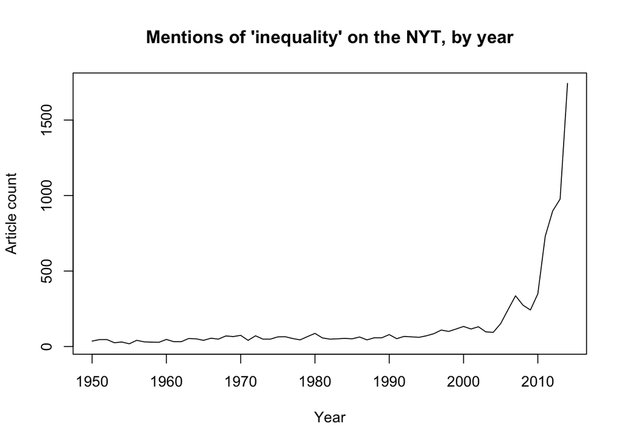

```r
plot(1950:2014, counts, type="l", main="Mentions of 'inequality' on the NYT, by year",
     xlab="Year", ylab="Article count")
```

Let’s try to generalize the function even more so that it works with any date interval, not just years:

```r
nyt_dates_count <- function(q, init, end, by){
  # sequence of dates to loop over
  dates <- seq(from=init, to=end, by=by)
  dates <- format(dates, "%Y%m%d") # changing format to match NYT API format
  counts <- rep(NA, length(dates)-1)
  # loop over periods
  for (i in 1:(length(dates)-1)){ ## note the -1 here
    # information message to track progress
    message(dates[i])
    # retrieve count
    counts[i] <- nyt_count(q=q, date1=dates[i],
                           date2=dates[i+1])
  }
  # improving this as well so that it returns a data frame
  df <- data.frame(date = as.Date(dates[-length(dates)], format="%Y%m%d"), count = counts)
  return(df)
}
```

And now we can count articles at the month level…

```r
counts <- nyt_dates_count(q="donald trump", init = as.Date("2014/01/01"), end = as.Date("2016/01/15"), by="month")
```

```
## 20140101
## 20140201
## 20140301
## 20140401
## 20140501
## 20140601
## 20140701
## 20140801
## 20140901
## 20141001
## 20141101
## 20141201
## 20150101
## 20150201
## 20150301
## 20150401
## 20150501
## 20150601
## 20150701
## 20150801
## 20150901
## 20151001
## 20151101
## 20151201
```

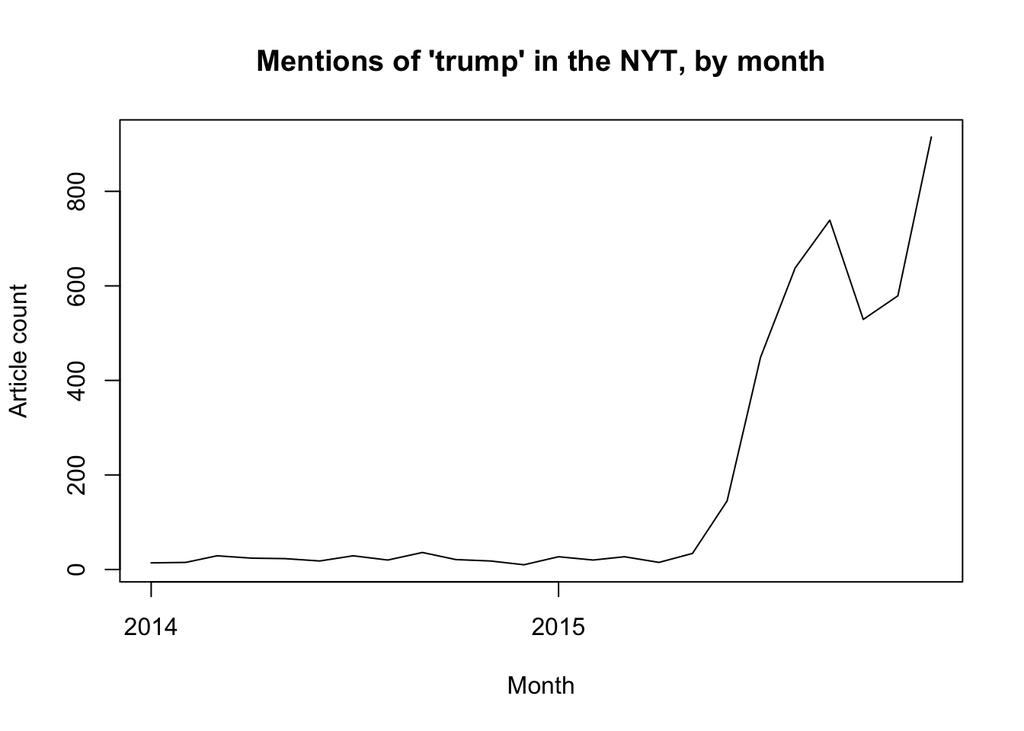

```r
plot(counts$date, counts$count, type="l", main="Mentions of 'trump' in the NYT, by month",
     xlab="Month", ylab="Article count")
```

And at the day level too…

```r
counts <- nyt_dates_count(q="sarah palin", init = as.Date("2016/01/01"), end = as.Date("2016/01/21"), by="day")
```

```
## 20160101
## 20160102
## 20160103
## 20160104
## 20160105
## 20160106
## 20160107
## 20160108
## 20160109
## 20160110
## 20160111
## 20160112
## 20160113
## 20160114
## 20160115
## 20160116
## 20160117
## 20160118
## 20160119
## 20160120
```

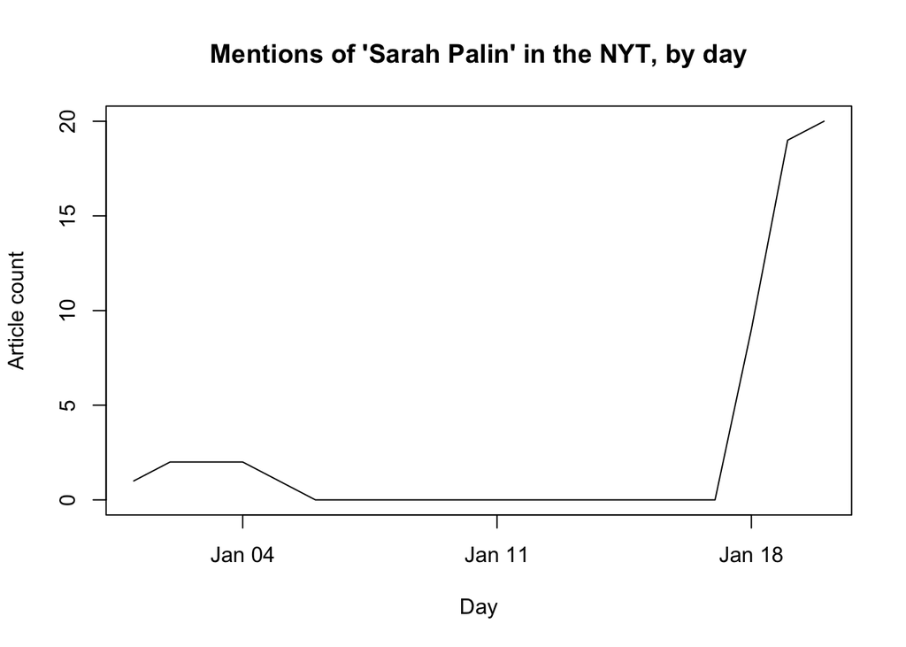

```r
plot(counts$date, counts$count, type="l", main="Mentions of 'Sarah Palin' in the NYT, by day",
     xlab="Day", ylab="Article count")
```